# Diabetes Sample Notebook 3a

## Tuned Decision Tree

### Recall that overfitting was a problem. Let's reduce overfitting by using Grid Search technique for hyperparameter tuning of the tree model.

> > In grid search, a predefined set of values is specified for each hyperparameter, and the algorithm evaluates all possible combinations of these values. Each combination is assessed using cross-validation to estimate the model's performance. Grid search provides an exhaustive search through the hyperparameter space.

### Note: Hyperparameter tuning methods are used to systematically explore the hyperparameter space of an ML algorithm. They are used to find the best combination of hyperparameter values that maximize the performance of the model.

### Other hyperparameter tuning options include:

- **Random Search:** Involves randomly sampling hyperparameter combinations from a predefined search space; it performs a specified number of iterations, each time evaluating the model's performance (using cross-validation) with a different set of hyperparameters
- **Bayesian Optimization:** Uses probabilistic models to model performance as a function of the hyperparameters. It uses this information to guide search towards promising regions in the hyperparameter space
- **Gradient-Based Optimization (e.g., Gradient Descent):** Can be used to optimize certain types of hyperparameters.

> > *The process of hyperparameter tuning involves iteratively training and evaluating the model with different hyperparameter configurations. It is often performed using cross-validation (a resampling method for estimating performance of an ML model), where the training data is split into multiple folds, and the model's performance is evaluated on each fold. In other words, the model is trained on a subset of the data (training set) and evaluated on the remaining subset (validation set). This process is repeated multiple times, with different subsets serving as the validation set each time. The performance of the model is then averaged over the validation sets to provide an estimate of how the model might perform on unseen data.*

```python
dtree_tuned = DecisionTreeClassifier(class_weight=class_weight_dict, random_state=1)

# Define hyperparameter grid
parameters = {
    'max_depth': np.arange(2, 10),
    'min_samples_leaf': [5, 7, 10, 15],
    'max_leaf_nodes': [2, 3, 5, 10, 15],
    'min_impurity_decrease': [0.0001, 0.001, 0.01, 0.1]
}

# Scoring function
scorer = metrics.make_scorer(metrics.recall_score)

# Grid search

grid_obj = GridSearchCV(dtree_tuned, parameters, scoring=scorer, n_jobs=-1)
grid_obj.fit(X_train, y_train)

# Best estimator
dtree_tuned = grid_obj.best_estimator_
dtree_tuned.fit(X_train, y_train)
```

```
DecisionTreeClassifier(class_weight={0: 0.7584745762711864,
                                     1: 1.4672131147540983},
                       max_depth=7, max_leaf_nodes=15,
                       min_impurity_decrease=0.0001, min_samples_leaf=5,
                       random_state=1)
```

```
Accuracy on training set :  0.8268156424581006
Accuracy on test set :  0.7792207792207793
Recall on training set :  0.7978142076502732
Recall on test set :  0.788235294117647
Precision on training set :  0.7227722772277227
Precision on test set :  0.67
F1 Score on training set :  0.7584415584415585
F1 Score on test set :  0.7243243243243244
```

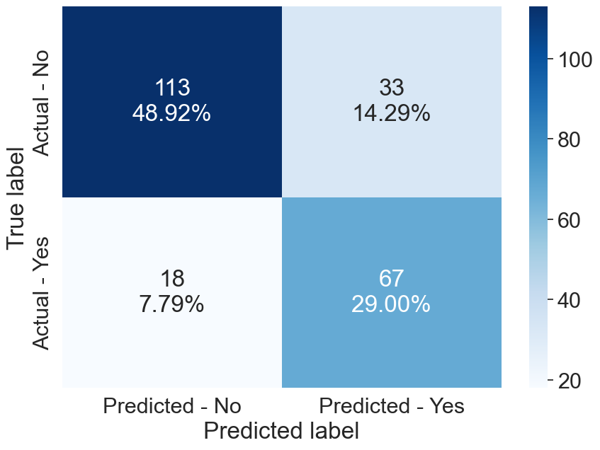

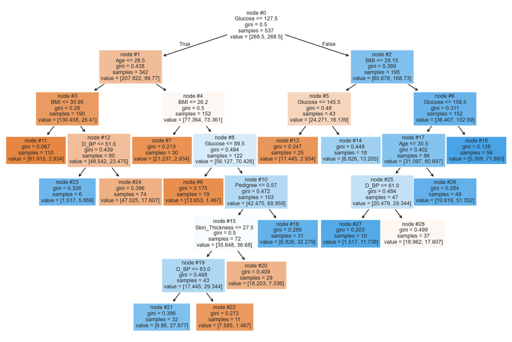

```python
# View metrics score
get_metrics_score(dtree_tuned)

# Create confusion matrix
make_confusion_matrix(dtree_tuned,y_test)

# Visualize tuned decision tree
plt.figure(figsize=(15,10))
out = tree.plot_tree(dtree_tuned,feature_names=feature_names,filled=True,fontsize=9,node_ids=True,class_names=None)
for o in out:
    arrow = o.arrow_patch
    if arrow is not None:
        arrow.set_edgecolor('black')
        arrow.set_linewidth(1)
plt.show()
```

```python
# Print text report showing the rules of the tuned decision tree
print(tree.export_text(dtree_tuned,feature_names=feature_names,show_weights=False))
```

```
|--- Glucose <= 127.50
|   |--- Age <= 28.50
|   |   |--- BMI <= 30.95
|   |   |   |--- class: 0
|   |   |--- BMI >  30.95
|   |   |   |--- D_BP <= 51.00
|   |   |   |   |--- class: 1
|   |   |   |--- D_BP >  51.00
|   |   |   |   |--- class: 0
|   |--- Age >  28.50
|   |   |--- BMI <= 26.20
|   |   |   |--- class: 0
|   |   |--- BMI >  26.20
|   |   |   |--- Glucose <= 89.50
|   |   |   |   |--- class: 0
|   |   |   |--- Glucose >  89.50
|   |   |   |   |--- Pedigree <= 0.57
|   |   |   |   |   |--- Skin_Thickness <= 27.50
|   |   |   |   |   |   |--- D_BP <= 83.00
|   |   |   |   |   |   |   |--- class: 1
|   |   |   |   |   |   |--- D_BP >  83.00
|   |   |   |   |   |   |   |--- class: 0
|   |   |   |   |   |--- Skin_Thickness >  27.50
|   |   |   |   |   |   |--- class: 0
|   |   |   |   |--- Pedigree >  0.57
|   |   |   |   |   |--- class: 1
|--- Glucose >  127.50
|   |--- BMI <= 28.15
|   |   |--- Glucose <= 145.50
|   |   |   |--- class: 0
|   |   |--- Glucose >  145.50
|   |   |   |--- class: 1
|   |--- BMI >  28.15
|   |   |--- Glucose <= 158.50
|   |   |   |--- Age <= 30.50
|   |   |   |   |--- D_BP <= 61.00
|   |   |   |   |   |--- class: 1
|   |   |   |   |--- D_BP >  61.00
|   |   |   |   |   |--- class: 0
|   |   |   |--- Age >  30.50
|   |   |   |   |--- class: 1
|   |   |--- Glucose >  158.50
|   |   |   |--- class: 1
```

## Bagging Classifier

The BaggingClassifier (Bootstrap Aggregating) is an ensemble meta-estimator that fits base classifiers on random subsets of the original dataset (with replacement) and aggregates their predictions to improve overall model stability and accuracy. By combining multiple models trained on different bootstrap samples, bagging helps reduce variance and overfitting compared to a single estimator.

It is particularly effective with high-variance, low-bias models like decision trees.

https://scikit-learn.org/stable/modules/generated/sklearn.ensemble.BaggingClassifier.html

```
Accuracy on training set :  0.9795158286778398
Accuracy on test set :  0.7489177489177489
Recall on training set :  0.9508196721311475
Recall on test set :  0.5176470588235295
Precision on training set :  0.9886363636363636
Precision on test set :  0.7213114754098361
F1 Score on training set :  0.9693593314763231
F1 Score on test set :  0.6027397260273972
```

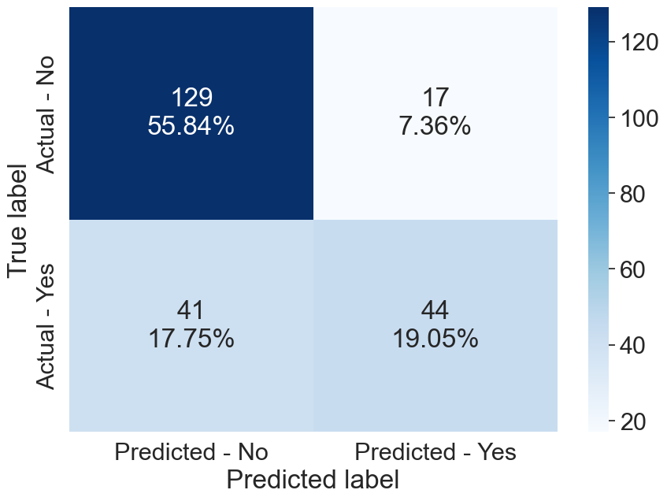

```python
# Fit the model
bagging_base = BaggingClassifier(random_state=1)
bagging_base.fit(X_train,y_train)

# Calculate metrics
get_metrics_score(bagging_base)

# Create the confusion matrix
make_confusion_matrix(bagging_base,y_test)
```

## Tuned Bagging Classifier

```python
# Define base BaggingClassifier
bagging_tuned = BaggingClassifier(random_state=1)

# Hyperparameter grid
parameters = {
    'max_samples': [0.7, 0.8, 0.9, 1],
    'max_features': [0.7, 0.8, 0.9, 1],
    'n_estimators': [10, 20, 30, 40, 50],
}

# Use recall as scoring metric
recall_scorer = metrics.make_scorer(metrics.recall_score)

# Setup GridSearchCV with parallel jobs and 5-fold CV
grid_obj = GridSearchCV(bagging_tuned, parameters, scoring=recall_scorer, cv=5, n_jobs=-1)

# Fit grid search
grid_obj.fit(X_train, y_train)

# Best estimator from grid search
bagging_tuned = grid_obj.best_estimator_

# Fit the best model on full training data
bagging_tuned.fit(X_train, y_train)
```

```
BaggingClassifier(max_features=0.9, max_samples=0.8, n_estimators=30,
                  random_state=1)
```

```
Accuracy on training set :  0.9888268156424581
Accuracy on test set :  0.7619047619047619
Recall on training set :  0.9726775956284153
Recall on test set :  0.5764705882352941
Precision on training set :  0.994413407821229
Precision on test set :  0.7205882352941176
F1 Score on training set :  0.9834254143646409
F1 Score on test set :  0.6405228758169934
```

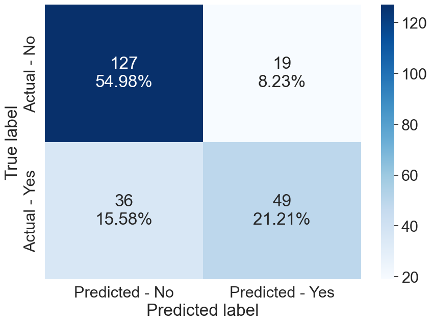

```python
get_metrics_score(bagging_tuned)

make_confusion_matrix(bagging_tuned,y_test)
```

## Random Forest

Random Forest is an ensemble learning method that constructs a multitude of decision trees during training and outputs the class that is the mode of the classes (classification) or mean prediction (regression) of the individual trees. It introduces randomness by selecting random subsets of features and data samples to build each tree, which helps reduce overfitting and improves generalization.

Because it aggregates many decision trees, Random Forest tends to be robust, accurate, and resistant to noise and outliers, making it one of the most popular machine learning algorithms for classification and regression tasks.

https://scikit-learn.org/stable/modules/generated/sklearn.ensemble.RandomForestClassifier.html

```
Accuracy on training set :  1.0
Accuracy on test set :  0.7878787878787878
Recall on training set :  1.0
Recall on test set :  0.6
Precision on training set :  1.0
Precision on test set :  0.7727272727272727
F1 Score on training set :  1.0
F1 Score on test set :  0.6754966887417219
```

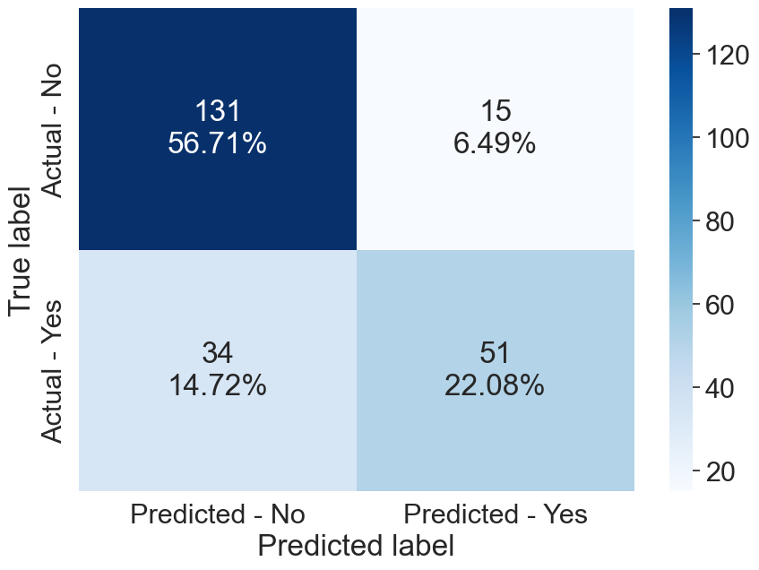

```python
# Fit the model
rf_base = RandomForestClassifier(random_state=1)
rf_base.fit(X_train,y_train)

# Calculate metrics
get_metrics_score(rf_base)

# Create the confusion matrix
make_confusion_matrix(rf_base,y_test)
```

## Tuned Random Forest

```python
%%time

from sklearn.ensemble import RandomForestClassifier
from sklearn.model_selection import GridSearchCV
from sklearn import metrics
import numpy as np

rf_tuned = RandomForestClassifier(class_weight={0:0.35,1:0.65}, random_state=1)

parameters = {
    'max_depth': list(np.arange(3, 10, 1)),
    'max_features': np.arange(0.6, 1.1, 0.1),
    'min_samples_split': np.arange(2, 20, 5),
    'n_estimators': np.arange(30, 160, 20),
    'min_impurity_decrease': [0.0001, 0.001, 0.01, 0.1]
}

scorer = metrics.make_scorer(metrics.recall_score)

grid_obj = GridSearchCV(rf_tuned, parameters, scoring=scorer, cv=5, n_jobs=-1)
grid_obj.fit(X_train, y_train)

rf_tuned = grid_obj.best_estimator_
rf_tuned.fit(X_train, y_train)
```

```
CPU times: total: 34.7 s
Wall time: 7min 12s
```

```
RandomForestClassifier(class_weight={0: 0.35, 1: 0.65}, max_depth=4,
                       max_features=0.7, min_impurity_decrease=0.0001,
                       min_samples_split=12, n_estimators=50, random_state=1)
```

```
Accuracy on training set :  0.8119180633147114
Accuracy on test set :  0.8225108225108225
Recall on training set :  0.8087431693989071
Recall on test set :  0.8
Precision on training set :  0.6915887850467289
Precision on test set :  0.7391304347826086
F1 Score on training set :  0.7455919395465995
F1 Score on test set :  0.768361581920904
```

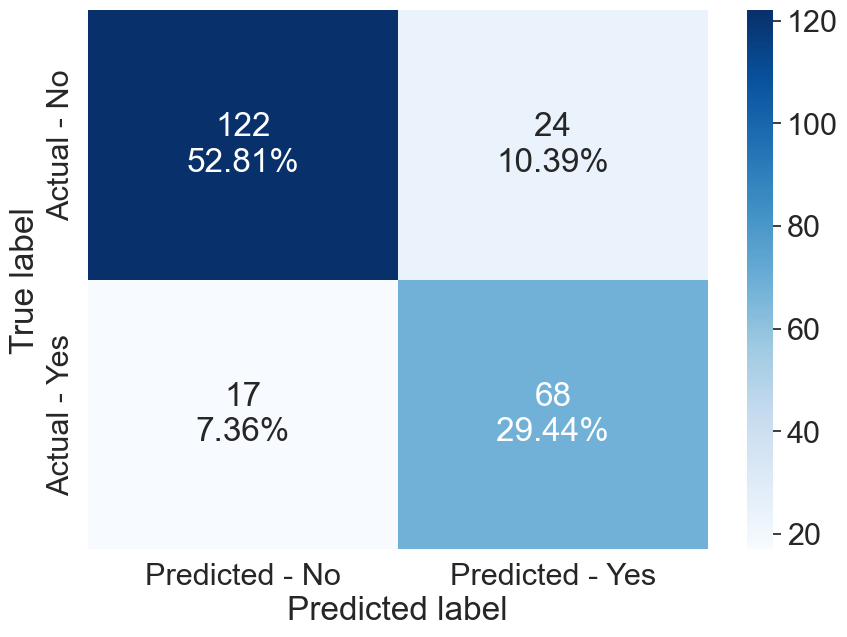

```
Accuracy on training set :  0.8119180633147114
Accuracy on test set :  0.8225108225108225
Recall on training set :  0.8087431693989071
Recall on test set :  0.8
Precision on training set :  0.6915887850467289
Precision on test set :  0.7391304347826086
F1 Score on training set :  0.7455919395465995
F1 Score on test set :  0.768361581920904
```

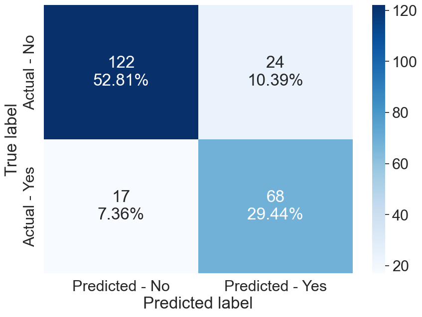

```python
#Calculating different metrics#Calculating different metrics
get_metrics_score(rf_tuned)

#Creating confusion matrix
make_confusion_matrix(rf_tuned,y_test)
get_metrics_score(rf_tuned)

#Creating confusion matrix
make_confusion_matrix(rf_tuned,y_test)
```

## Comparing Supervised ML Classification Models

```python
# Identify the models to compare
models = [dtree_base, dtree_tuned, bagging_base, bagging_tuned, rf_base, rf_tuned]

# Define empty lists to store results
acc_train = []
acc_test = []
recall_train = []
recall_test = []
precision_train = []
precision_test = []
f1_train = []
f1_test = []

# Loop through all models to collect metrics (Accuracy, Recall, Precision, F1)
for model in models:
    scores = get_metrics_score(model, False)
    acc_train.append(scores[0])
    acc_test.append(scores[1])
    recall_train.append(scores[2])
    recall_test.append(scores[3])
    precision_train.append(scores[4])
    precision_test.append(scores[5])
    f1_train.append(scores[6])
    f1_test.append(scores[7])
```

```python
# Compare models on evaluation metrics

comparison_frame = pd.DataFrame({
    'Model': ['Decision Tree', 'Tuned Decision Tree', 'Bagging Classifier', 'Tuned Bagging Classifier', 'Random Forest', 'Tuned Random Forest'],
    'Train_Accuracy': acc_train,
    'Test_Accuracy': acc_test,
    'Train_Recall': recall_train,
    'Test_Recall': recall_test,
    'Train_Precision': precision_train,
    'Test_Precision': precision_test,
    'Train_F1': f1_train,
    'Test_F1': f1_test
})

# Sort models in decreasing order of most important metric
comparison_frame_sorted = comparison_frame.sort_values(by='Test_Recall', ascending=False)

# Set display options to avoid wrapping wide DataFrames
pd.set_option('display.width', 200)
pd.set_option('display.max_columns', None)

# Print sorted DataFrame
print(comparison_frame_sorted)
```

```
                      Model  Train_Accuracy  Test_Accuracy  Train_Recall  Test_Recall  Train_Precision  Test_Precision  Train_F1  Test_F1
5       Tuned Random Forest           0.812          0.823         0.809        0.800            0.692           0.739     0.746    0.768
1       Tuned Decision Tree           0.827          0.779         0.798        0.788            0.723           0.670     0.758    0.724
0             Decision Tree           1.000          0.719         1.000        0.612            1.000           0.619     1.000    0.615
4             Random Forest           1.000          0.788         1.000        0.600            1.000           0.773     1.000    0.675
3  Tuned Bagging Classifier           0.989          0.762         0.973        0.576            0.994           0.721     0.983    0.641
2        Bagging Classifier           0.980          0.749         0.951        0.518            0.989           0.721     0.969    0.603
```

### View most important features

```
Gini Importance - Tuned Random Forest

                Importance
Glucose              0.438
BMI                  0.270
Age                  0.127
Pedigree             0.073
Pregnancies          0.039
D_BP                 0.026
Skin_Thickness       0.016
Insulin              0.010
```

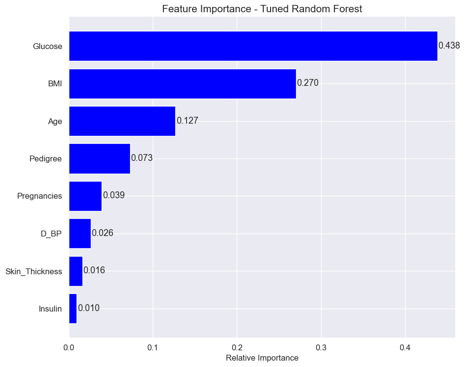

```python
# Step 0: Set your best model
best_model = rf_tuned      # Change this as needed

# Step 1: Feature names (assumes X_train is a pandas DataFrame)
feature_names = X_train.columns.tolist()

# Step 2: Human-readable name mapping
model_name_map = {
    id(dtree_tuned): "Tuned Decision Tree",
    id(bagging_tuned): "Tuned Bagging Classifier",
    id(rf_tuned): "Tuned Random Forest"
}

model_name = model_name_map.get(id(best_model), type(best_model).__name__)

# Step 3: Get feature importances
if hasattr(best_model, "feature_importances_"):
    importances = best_model.feature_importances_
elif hasattr(best_model, "estimators_"):
    importances = np.mean(
        [est.feature_importances_ for est in best_model.estimators_],
        axis=0
    )
else:
    raise ValueError("This model does not support feature importances.")

# Step 4: Print Gini importances as a DataFrame
gini_df = pd.DataFrame(importances, columns=["Importance"], index=feature_names)
gini_df = gini_df.sort_values(by="Importance", ascending=False)
print(f"\nGini Importance - {model_name}\n")
print(gini_df)

# Step 5: Plot feature importance
indices = np.argsort(importances)[::-1]

plt.figure(figsize=(10, 8))
plt.title(f'Feature Importance - {model_name}', fontsize=15)
plt.barh(range(len(indices)), importances[indices], color='blue', align='center')

# Adjust axis labels and tick font sizes
plt.yticks(range(len(indices)), [feature_names[i] for i in indices], fontsize=12)
plt.xticks(fontsize=12)
plt.xlabel('Relative Importance', fontsize=12)

# Annotate each bar with importance value
for i, idx in enumerate(indices):
    val = importances[idx]
    label = "<0.001" if val < 0.001 else f"{val:.3f}"
    plt.text(val + 0.001, i, label, va='center', fontsize=13)

plt.tight_layout()
plt.gca().invert_yaxis()
plt.show();
```